# Excess death in relation to Covid-19

15 de May, 2020

# Aim

This project aims to estimate a risk factor connected to excess death and analyse the correlation between this excess and reported cases of Covid-19.

# Data

The data used is weekly data of the total number of deaths in the following countries:

The data is obtained for week 2- 17 for 2020-2018 for all the countries and some additional years for some of the countries. The data is retrieved from national statistic centers for the recpectiv countries, see the bibliografy.

To be able to preform analytics all data were transformed to the same structure visualized bellow.

Later on the weekly number of corrona registered deaths will also be used.

```r
head(read.csv("data/Death_week_2_17_netherland.csv", sep = ";"))
```

|  | week | X2019 | X2018 | X2017 | X2020 | average |
| --- | --- | --- | --- | --- | --- | --- |
| 1 | 2 | 3262 | 3359 | 3637 | 3364 | 3637 |
| 2 | 3 | 3150 | 3364 | 3487 | 3152 | 3487 |
| 3 | 4 | 3178 | 3322 | 3626 | 3041 | 3626 |
| 4 | 5 | 3143 | 3403 | 3574 | 3158 | 3574 |
| 5 | 6 | 3185 | 3513 | 3446 | 3189 | 3446 |
| 6 | 7 | 3252 | 3660 | 3417 | 3195 | 3417 |

# Model

The distribution used will be

Hence the model will estimate the risk factor $\theta_{i,2020}$. If 1 is outside of the credibal intervals the risk will be considerd significant and we can assume there is a precanse of exsess death.

The $log(\theta_i)$ are assumed to follow a normal distribution with parameters

$log(\theta_i)\sim Normal(\mu_i,\sigma_i)$ (#this might also change slightly)

with $\mu_i$ and $\sigma_i$ again are normaly distributed with shared hyperparameters.

# Analysis

Reading the data

```r
data_netherland<- read.csv("data/Death_week_2_17_netherland.csv", sep = ";")
data_england_wales <- read.csv("data/England_Wales_weekly.csv",sep = ";")
data_italy <- read.csv("data/italy_week_deaths.csv", sep = ",")
data_norway<- read.csv("data/Norway_total_death.csv", sep = ";")
data_germany <- read.csv("data/germany.csv", sep = ";")
```

```r
mean_germany <- rowMeans(data_germany[, c(2,3,4,5)])
```

Extracting the data for the Netherland

```r
mean_netherland <- as.vector(as.matrix(data_netherland)[,6])
netherland_2020<-as.vector(as.matrix(data_netherland)[,5])
```

Extracting data England and Wales

```r
mean_england <- as.vector(as.matrix(data_england_wales)[,12])
england_2020 <- as.vector(as.matrix(data_england_wales)[,13])
```

Extracting data Italy

```r
mean_italy <- as.vector(as.matrix(data_italy)[,9])
italy_2020 <- as.vector(as.matrix(data_italy)[,8])
```

Extracting the data for Norway

```r
mean_norway <- as.vector(as.matrix(data_norway)[,8])
norway_2020<-as.vector(as.matrix(data_norway)[,7])
```

### Setting up the stan lists

```r
create_list <- function(N, E, O){
  data_list <-  list(
  N = N,
  E = E,
  O = O,
  phi_a = 1,
  phi_b = 6000,
  sigma_a = 0.01,
  sigma_b = 4,
  alpha_mu = 0,
  alpha_sigma = 4,
  beta_a = -1,
  beta_b = 1,
  sigma_time_mu = 0,
  sigma_time_sigma= 25
  )
  return(data_list)
}
```

```r
data_list_netherland <- create_list(length(mean_netherland), mean_netherland, netherland_2020)
data_list_england_wales <- create_list( length(mean_england),mean_england,england_2020 )
data_list_italy <- create_list(length(mean_italy), mean_italy, italy_2020)
data_list_norway <- create_list(length(mean_norway), mean_norway, norway_2020)
```

Fit the stan models

```r
risk_netherland <- stan(params$stanfile, iter = params$iter, chains = 4,
  data = data_list_netherland, seed = 1, control = list(adapt_delta = params$adapt_delta, max_treedepth = params$max_treedepth))
```

```
## Trying to compile a simple C file
```

```r
risk_england_wales <- stan(params$stanfile, iter = params$iter, chains = 4,
  data = data_list_england_wales, seed = 1, control = list(adapt_delta = params$adapt_delta, max_treedepth = params$max_treedepth))
risk_italy <- stan(params$stanfile, iter = params$iter, chains = 4,
  data = data_list_italy, seed = 1, control = list(adapt_delta = params$adapt_delta, max_treedepth = params$max_treedepth))
risk_norway <- stan(params$stanfile, iter = params$iter, chains = 4,
  data = data_list_norway, seed = 1, control = list(adapt_delta = params$adapt_delta, max_treedepth = params$max_treedepth))
```

There is a problem with divergency in our model meaning means and medians could be unreliable.

To explore this a bit more the pairs() function suggested by R are used.

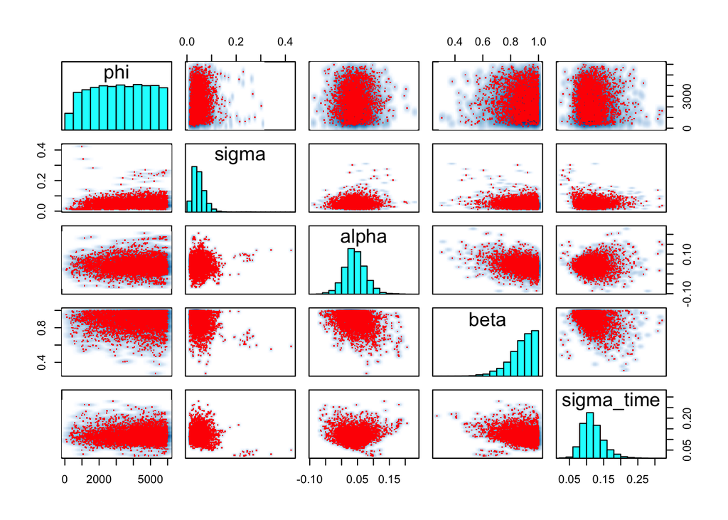

```r
pairs(risk_netherland, pars = c("phi", "sigma", "alpha", "beta", "sigma_time"))
```

# Funtions

Funciton for outputgraphs

```r
plot_risk <- function(data, country_name){
  g<- ggplot(data = data, aes(x = week, y = theta)) + geom_point() + geom_line(lty = 2) +
  geom_line(aes(week, CI_lower), col = "blue", lty = 2) +
  geom_line(aes(week, CI_upper), col = "blue", lty = 2) +
  geom_hline(yintercept = 1, col = "red")+
  ggtitle("Riskfactor for" , country_name)

  return(g)
}
```

Function for creating the dataframe with thetas and the bounds for the credible interval.

```r
create_CI_theta_vec <- function(risk_data, N){
  fit<-summary(risk_data)
  results <- as.data.frame(fit$summary)

  CI_upper <- exp(results$`97.5%`[1:N] +results$`97.5%`[(N+1):(2*N)])
  CI_lower <- exp(results$`2.5%`[1:N] +results$`2.5%`[(N+1):(2*N)])

  theta <- exp(results$mean[1:N] +results$mean[(N+1):(2*N)])
  week <- seq(1:N)
  data <- data.frame(week, CI_upper, CI_lower, theta)
  return(data)

}
```

# Results

## Netherland

```r
print(risk_netherland)
```

```
## Inference for Stan model: Neg_bin_time_dep.
## 4 chains, each with iter=5000; warmup=2500; thin=1;
## post-warmup draws per chain=2500, total post-warmup draws=10000.
##
##                         mean se_mean      sd      2.5%       25%       50%
## log_theta[1]           -0.05    0.00    0.03     -0.11     -0.07     -0.05
## log_theta[2]            0.00    0.00    0.05     -0.10     -0.03      0.00
## log_theta[3]           -0.01    0.00    0.05     -0.11     -0.04     -0.01
## log_theta[4]            0.00    0.00    0.04     -0.09     -0.03      0.00
## log_theta[5]            0.00    0.00    0.05     -0.09     -0.02      0.00
## log_theta[6]            0.00    0.00    0.04     -0.08     -0.02      0.00
## log_theta[7]           -0.02    0.00    0.05     -0.12     -0.04     -0.02
## log_theta[8]            0.00    0.00    0.05     -0.10     -0.02      0.00
## log_theta[9]           -0.01    0.00    0.05     -0.13     -0.04     -0.01
## log_theta[10]          -0.01    0.00    0.05     -0.11     -0.03     -0.01
## log_theta[11]           0.00    0.00    0.04     -0.10     -0.03      0.00
## log_theta[12]           0.01    0.00    0.05     -0.08     -0.02      0.01
## log_theta[13]           0.03    0.00    0.05     -0.05      0.00      0.02
## log_theta[14]           0.02    0.00    0.05     -0.07     -0.01      0.01
## log_theta[15]           0.00    0.00    0.05     -0.09     -0.03      0.00
## log_theta[16]          -0.01    0.00    0.05     -0.13     -0.04     -0.01
## log_theta_time[1]      -0.02    0.00    0.06     -0.15     -0.05     -0.02
## log_theta_time[2]      -0.10    0.00    0.05     -0.20     -0.13     -0.10
## log_theta_time[3]      -0.16    0.00    0.05     -0.25     -0.19     -0.16
## log_theta_time[4]      -0.12    0.00    0.05     -0.22     -0.15     -0.12
## log_theta_time[5]      -0.08    0.00    0.05     -0.18     -0.11     -0.08
## log_theta_time[6]      -0.07    0.00    0.05     -0.16     -0.10     -0.07
## log_theta_time[7]      -0.09    0.00    0.05     -0.19     -0.13     -0.10
## log_theta_time[8]      -0.02    0.00    0.05     -0.12     -0.05     -0.02
## log_theta_time[9]       0.03    0.00    0.06     -0.07     -0.01      0.03
## log_theta_time[10]      0.13    0.00    0.05      0.04      0.10      0.13
## log_theta_time[11]      0.27    0.00    0.05      0.17      0.24      0.26
## log_theta_time[12]      0.43    0.00    0.05      0.32      0.40      0.43
## log_theta_time[13]      0.57    0.00    0.06      0.45      0.54      0.57
## log_theta_time[14]      0.55    0.00    0.05      0.44      0.52      0.55
## log_theta_time[15]      0.45    0.00    0.05      0.35      0.43      0.45
## log_theta_time[16]      0.39    0.00    0.06      0.28      0.35      0.39
## phi                  3200.37   64.01 1623.45    435.65   1821.54   3219.51
## sigma                   0.05    0.00    0.03      0.01      0.03      0.04
## alpha                   0.04    0.00    0.03     -0.02      0.02      0.04
```

[output cut: 32 more lines]

```
## log_theta_time[13]      0.60      0.66   587 1.02
## log_theta_time[14]      0.58      0.65   675 1.01
## log_theta_time[15]      0.48      0.55   735 1.00
## log_theta_time[16]      0.42      0.51   742 1.01
## phi                  4596.67   5848.07   643 1.00
## sigma                   0.06      0.11   328 1.01
## alpha                   0.06      0.11  1092 1.00
## beta                    0.95      1.00   991 1.00
## sigma_time              0.13      0.19   915 1.00
## lp__               416844.69 416854.86   432 1.01
##
## Samples were drawn using NUTS(diag_e) at Fri May 15 11:27:04 2020.
## For each parameter, n_eff is a crude measure of effective sample size,
## and Rhat is the potential scale reduction factor on split chains (at
## convergence, Rhat=1).
```

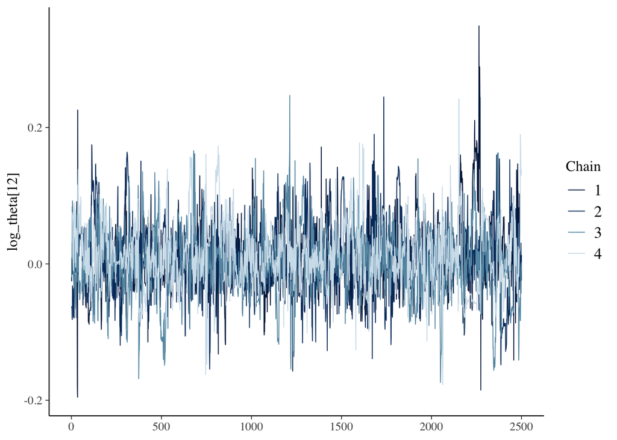

```r
library(bayesplot)
posterior <- as.data.frame(risk_netherland)
mcmc_trace(risk_netherland, pars = "log_theta[12]")
```

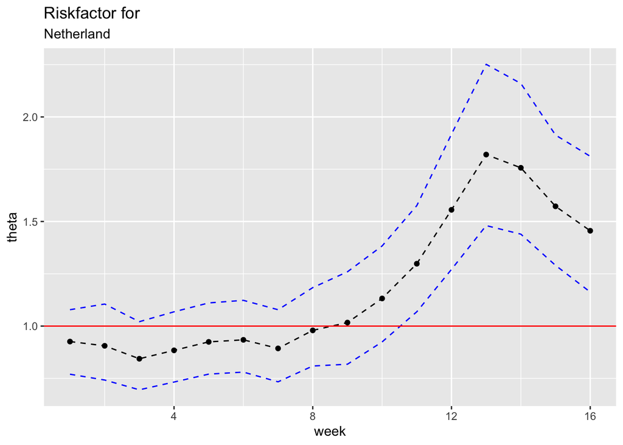

```r
data_netherland <- create_CI_theta_vec(risk_netherland, length(mean_netherland))
plot_risk(data_netherland, "Netherland")
```

## England and Wales

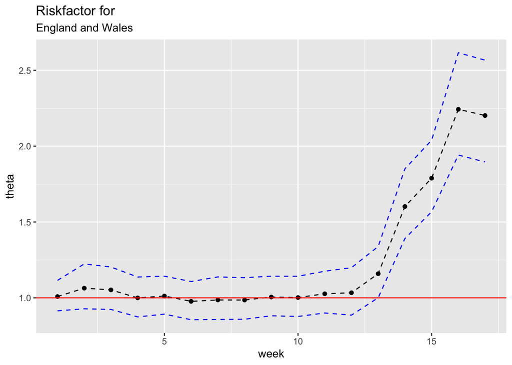

```r
data_england_wales <- create_CI_theta_vec(risk_england_wales, length(mean_england))
plot_risk(data_england_wales, "England and Wales")
```

## Italy

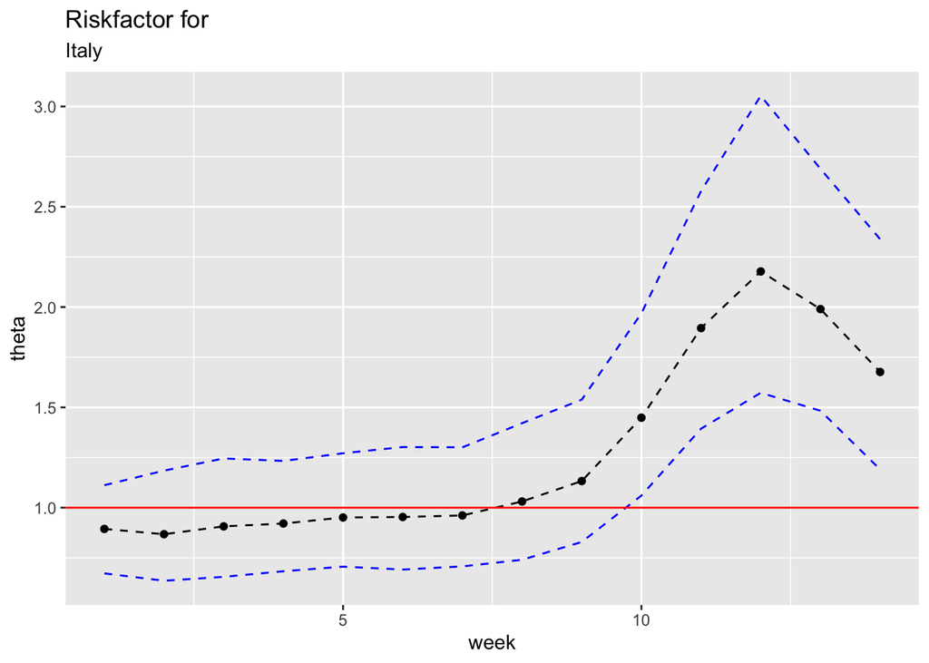

```r
data_italy <- create_CI_theta_vec(risk_italy, length(mean_italy))
plot_risk(data_italy, "Italy")
```

## Norway

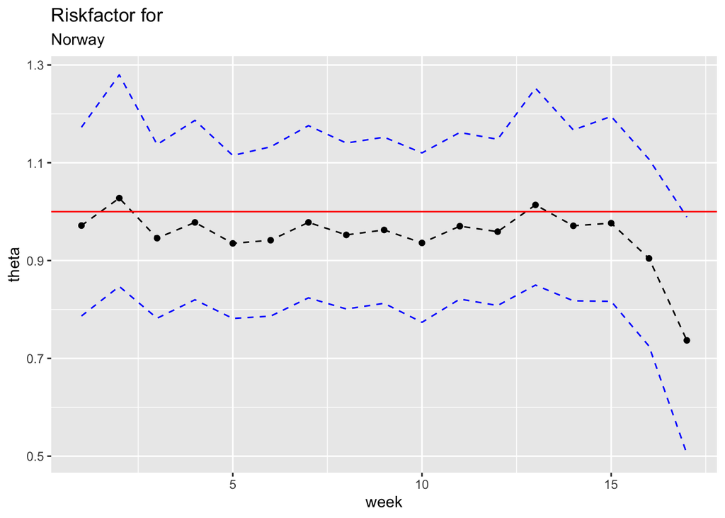

```r
data_norway <- create_CI_theta_vec(risk_norway, length(mean_norway))
plot_risk(data_norway, "Norway")
```

notice: negative risk in week 17!! Consistent with dat a:) (norway goes from 2-17 in weeks)

# Possible extentions

To extend the model one could explore an hierarchical model adding the different countries to the same model, add explanatory variables for the risk $\theta_i$ (% of elderly people, % smokers, % obecity, % time of lockdown).

$log(\theta_i) \sim Normal(\beta_i + \beta_1 X_1 + \beta_2 X_2,\sigma_i^2)$

Also we would like to explore the possibility of doing the same model with E_i changing to the historical average plus the number of registered covid-19 deaths. Then the risk factor theta could share some light on how much unexplaind death occures in the different countries.